# Better Indexes: Farmer Input, Local Design Breakthroughs in Zambia

[figure not shown]

*The tools on this page are the out of date versions, used in the past and are only for illustration of past processes. The new suite of tools will soon be released publicly!*

### How do we work with farmers to fix index insurance?

Too often index insurance fails to provide payouts when farmers really need it. To fix that we work with the farmers themselves. **We have found that farmers themselves can design indexes at least as good, or better than any index or area yield insurance product ever provided by international experts for them.** These indexes are improved even more when optimized by local, government, and international experts.

**For basis risk, transparency, and agency reasons, it is clear that experts and insurance companies should only be providing the indexes if they can demonstrate they are outperforming what the end beneficiaries could do themselves.**

One example is in Zambia (https://fist.iri.columbia.edu/publications/docs/zambia_fisp_yieldaudit_2023/). The government of Zambia with technical support from IRI and WFP has had focus group meetings in more than every seventh village in the country this year, asking farmers what they need in insurance. Check out the impressive database tree of villages visited at the link below (or start the animation). Keep in mind that although this example from Zambia is particularly large scale, these focus groups are now very practical exercises, and have been regularly performed in many countries, at low costs, with similar outcomes.

https://fist-cleandat.iri.columbia.edu/viewrec2

[video not shown]

### How do we clean farmer data?

Farmer recollections are not perfect. To use them to fix index insurance experts must clean the data, similar to the cleaning process in a clinical study. Zambian experts compared answers and discussion across villages in a district, review the notes of the village meetings, and follow up on concerns, reconciling the villages in a district into a district level summary.

[figure not shown]

Click on the link below to peek at the tool Zambian experts have used to perform this cleaning process, as well as the details of what farmers said in focus groups.

https://fist-cleandat.iri.columbia.edu/comzambia

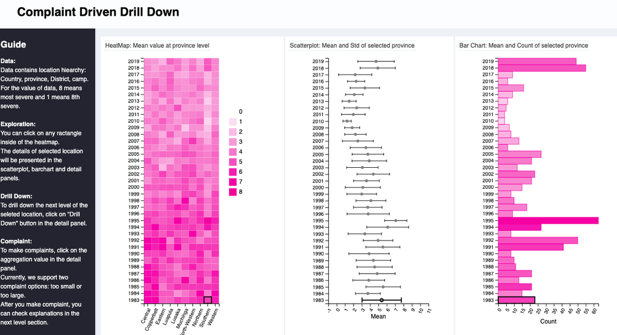

Try clicking on a province (in pink, eg southern) and see how farmers talked about years like 2018, and 1995. Its possible to drill down to a village and see the details of each discussion! This information, along with historical yields allows local experts to determine standards for what needs insurance should address. Thanks to our friends Zachary Huang and our other friends at The Columbia University’s Data Science Institute for making this possible! These will be reconciled with yield data and satellites in later steps

### How do we use farmer information to fix indexes?

To fix the insurance, we get input from the farmers that can directly be used in designing better indexes: What years were the most challenging? And what times during the year they are most at risk? Government experts check if historical satellite datasets during the risky times of year reflect the bad years farmers reported to find improvements. These are cross checked against the historical yield data, and the documented crop agronomics. This process provides the information that the farmers themselves can directly review and approve, refuse, or improve in the next round of crowdsourcing.

If the agreement is low, there are problems that need to be solved for the insurance to be responsible. If agreement is high, it is worth moving forward.

Click on the link to check out this tool that Zambian experts are using to understand the potential for improving index insurance.

If the page doesnt load, try an incognito window

https://columbia-desdr.github.io/Sliders-zambia/

[figure not shown]

You can select pretty much any district in Zambia and then drag the timing blue bars for different satellites/algorithms to see what the agreement is between the satellites, farmers recollections, and the government yield datasets. The defaults are from the risky times reported by farmers–See if you can improve it!

For the real project, the next step is to send the analysis to the insurance companies as a specification/standard for what an insurance product should do.

### What’s the backstory, and what’s next (with the crowd-software for indexinsurance)?

These tools that local experts use farmer input to fix index insurance using the latest datascience and remotesensing are prototypes. Driven by operational demands and insights over the past dozen(ish) years from projects such as the [World Food Program R4](https://www.wfp.org/r4-rural-resilience-initiative), we were able to transform software and processes initially funded by USAID with transformational resources from [ACToday](https://iri.columbia.edu/news/2021-actoday-highlight-helping-provide-insurance-to-a-million-smallholder-farmers/), [World Bank Group’s Next Generation Drought Insurance project](https://iri.columbia.edu/news/improving-risk-indicators-introducing-the-next-generation-drought-index-project/).

You can check out the Next Generation Drought Insurance materials here: https://fist.iri.columbia.edu/publications/docs/ngdisentraining/ and play with the tool itself here (username WB and password IRI): https://fist-shiny.iri.columbia.edu/WB_Senegal/optimization_app/

[figure not shown]

But these are only prototype solutions. Seed funding from the [Columbia University Data Science Institute](https://datascience.columbia.edu/), [CCAFS](https://ccafs.cgiar.org/) and [Earth Institute, now known as the Climate School](https://www.climate.columbia.edu/) helped make new projects like the [NSF funded DESDR](https://www.nsf.gov/awardsearch/showAward?AWD_ID=2103794&HistoricalAwards=false) (pronounced DECIDER if you want to be fun) possible to strengthen these prototypes into software frameworks strong enough to be configured and applied in a range of contexts. But there is a lot of work that needs to be done!

In this [State of the Planet Blog](https://iri.columbia.edu/news/in-new-project-millions-of-farmers-will-help-to-improve-insurance-against-climate-disasters) we discuss the backstory and future of this work:

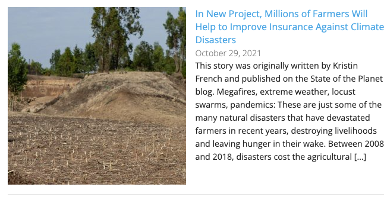

Stay tuned!